# Week7a Lab: Map Using Cat Data

Caroline

2023-03-09

# **Quick Summary**

Here we will be using the Cats Data from *TidyTuesday 2023/01/31* and will be following these steps:

1. Load the libraries needed to use specific functions
2. Load the data that we will be using throughout this script
3. Create a map of tracked pet cats based on longitude and latitude coordinates

# **Loading Data**

### *Load Libraries*

```r
library(tidyverse)
library(sf)
library(tmap)
```

### *Load cat data*

This is the data that we will be using for this script:

```r
# Get the Data

# Read in with tidytuesdayR package
# Install from CRAN via: install.packages("tidytuesdayR")
# This loads the readme and all the datasets for the week of interest

# Either ISO-8601 date or year/week works!

tuesdata <- tidytuesdayR::tt_load('2023-01-31')
tuesdata <- tidytuesdayR::tt_load(2023, week = 5)
cats_uk <- tuesdata$cats_uk
cats_uk_reference <- tuesdata$cats_uk_reference
```

This is just to visualize a summary of the data:

```r
# Check the structure of the data
glimpse(cats_uk)
```

```
## Rows: 18,215
## Columns: 11
## $ tag_id                   <chr> "Ares", "Ares", "Ares", "Ares", "Ares", "Ares…
## $ event_id                 <dbl> 3395610551, 3395610552, 3395610553, 339561055…
## $ visible                  <lgl> TRUE, TRUE, TRUE, TRUE, TRUE, TRUE, TRUE, TRU…
## $ timestamp                <dttm> 2017-06-24 01:03:57, 2017-06-24 01:11:20, 20…
## $ location_long            <dbl> -5.113851, -5.113851, -5.113730, -5.113774, -…
## $ location_lat             <dbl> 50.17032, 50.17032, 50.16988, 50.16983, 50.17…
## $ ground_speed             <dbl> 684, 936, 2340, 0, 4896, 504, 108, 504, 252, …
## $ height_above_ellipsoid   <dbl> 154.67, 154.67, 81.35, 67.82, 118.03, 123.07,…
## $ algorithm_marked_outlier <lgl> FALSE, FALSE, FALSE, FALSE, FALSE, FALSE, FAL…
## $ manually_marked_outlier  <lgl> FALSE, FALSE, FALSE, FALSE, FALSE, FALSE, FAL…
## $ study_name               <chr> "Pet Cats United Kingdom", "Pet Cats United K…
```

# **Filter Data**

### *Pull columns “location_long” and “location_lat”*

Now we are filtering out specific columns to map and setting all the different parameters. Note, These columns contain the longitude and latitude coordinates for each data point. I’m using these columns to create a map showing the location of each data point:

```r
# Create sf object
cats_sf <- st_as_sf(cats_uk, coords = c("location_long", "location_lat"), crs = 4326)
```

# **Create Map**

### *Create Map of UK*

Here we are pulling all of the coordinates to create a map of the UK that will be used for the overlapping cat datapoints:

```r
# Create UK map
uk_map <- map_data("world", "UK")
```

### *Create Map of cats*

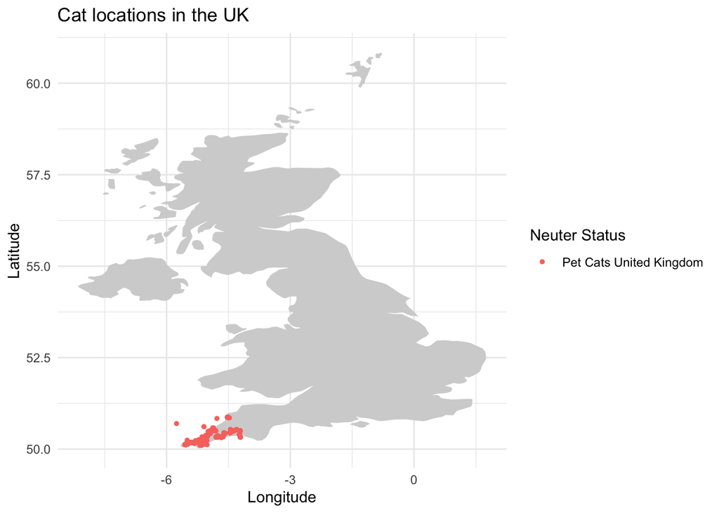

```r
# Create map
ggplot() +
  geom_polygon(data = uk_map, aes(x = long, y = lat, group = group), fill = "lightgray") +
  geom_point(data = cats_uk, aes(x = location_long, y = location_lat, color = study_name), size = 1) +
  labs(title = "Cat locations in the UK", x = "Longitude", y = "Latitude", color = "Neuter Status") +
  theme_minimal()
```